# Scotland Lip Cancer

Nicholas Bradley

2025-05-11

# Introduction

In this analysis I estimate the risk of lip cancer in males in Scotland. I use data on the number of observed and expected lip cancer cases, and the proportion of population engaged in agriculture, fishing, or forestry (AFF) for each of the Scotland counties. First, I describe how to calculate and interpret the standardized incidence ratios (SIRs) in the Scotland counties. Then, I show how to fit the Besag-York-Mollié (BYM) model to obtain relative risk estimates and quantify the effect of the AFF variable. I also show how to calculate exceedance probabilities of relative risk being greater than a given threshold value. Results are shown by means of tables, static plots and interactive maps created with leaflet.

## Examine the Data

```r
class(Scotland)
```

```
## [1] "list"
```

```r
names(Scotland)
```

```
## [1] "geo"             "data"            "spatial.polygon" "polygon"
```

## Data Description

Scotland is a list object with the following elements:

geo: data frame with names and centroid coordinates (eastings/northings) of each of the counties, data: data frame with names, number of observed and expected lip cancer cases, and AFF values of each of the counties, spatial.polygon: SpatialPolygons object with the map of Scotland, polygon: polygon map of Scotland.

I can type head(scotland$data) to see the number of observed and expected lip cancer cases and the AFF values of the first counties.

```r
head(Scotland$data)
```

```
##    county.names cases expected  AFF
## 1 skye-lochalsh     9      1.4 0.16
## 2  banff-buchan    39      8.7 0.16
## 3     caithness    11      3.0 0.10
## 4  berwickshire     9      2.5 0.24
## 5 ross-cromarty    15      4.3 0.10
## 6        orkney     8      2.4 0.24
```

The map of Scotland counties is given by the SpatialPolygons object called Scotland$spatial.polygon

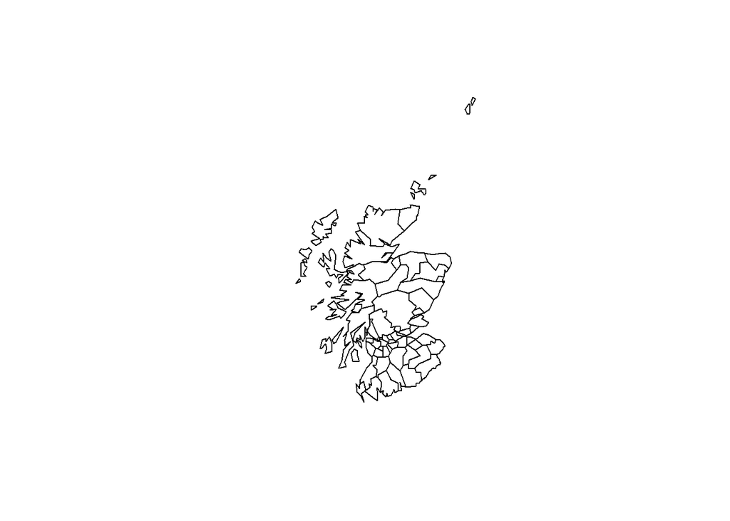

```r
map <- Scotland$spatial.polygon
map <- st_as_sf(map)
plot(st_geometry(map))  # correctly plots an sf object
```

map does not contain information about the Coordinate Reference System (CRS), so we specify a CRS by assigning the corresponding proj4 string to the map. The map is in the projection OSGB 1936/British National Grid which has EPSG code 27700. The proj4 string of this projection can be seen in https://spatialreference.org/ref/epsg/27700/. I assign this proj4 string to map and set +units=km because this is the unit of the map projection.

```r
map <- Scotland$spatial.polygon
proj4string(map) <- CRS("+proj=tmerc +lat_0=49 +lon_0=-2
  +k=0.9996012717 +x_0=400000 +y_0=-100000 +datum=OSGB36
  +units=km +no_defs")
map <- st_as_sf(map)  # now convert to sf
```

I wish to use the leaflet package to create maps. leaflet expects data to be specified in latitude and longitude using WGS84, so I transform map to this projection by first converting map from a sp to a sf object, and then using st_transform() to convert the coordinates.

```r
library(sf)
map <- st_as_sf(map)
map <- st_transform(map, crs = 4326)
```

## Data Preparation

In order to analyze the data, I create a data frame called d with columns containing the counties ids, the observed and expected number of lip cancer cases, the AFF values, and the SIRs. Specifically, d contains the following columns:

county: id of each county, Y: observed number of lip cancer cases in each county, E: expected number of lip cancer cases in each county, AFF: proportion of population engaged in agriculture, fishing, or forestry, SIR: SIR of each county. I create the data frame d by selecting the columns of scotland$data that denote the counties, the number of observed cases, the number of expected cases, and the variable AFF. Then we set the column names of the data frame to c(“county”, “Y”, “E”, “AFF”).

```r
d <- Scotland$data[, c("county.names", "cases", "expected", "AFF")]
names(d) <- c("county", "Y", "E", "AFF")
```

I can compute the SIR values as the ratio of the observed to the expected number of lip cancer cases.

```r
d$SIR <- d$Y / d$E
```

The first rows of the data frame d are the following:

```r
head(d)
```

```
##          county  Y   E  AFF      SIR
## 1 skye-lochalsh  9 1.4 0.16 6.428571
## 2  banff-buchan 39 8.7 0.16 4.482759
## 3     caithness 11 3.0 0.10 3.666667
## 4  berwickshire  9 2.5 0.24 3.600000
## 5 ross-cromarty 15 4.3 0.10 3.488372
## 6        orkney  8 2.4 0.24 3.333333
```

## Adding data to map

The map with the counties map and the data d contains the Scotland counties in the same order. I join the data to the map as follows:

```r
map <- cbind(map, d)
```

The first part of the data by typing head(map). Here the first column corresponds to the row names of the data, and the rest of the columns correspond to the variables county, Y, E, AFF and SIR.

```r
head(map)
```

```
## Simple feature collection with 6 features and 5 fields
## Geometry type: MULTIPOLYGON
## Dimension:     XY
## Bounding box:  xmin: -6.789691 ymin: 55.63418 xmax: -1.791961 ymax: 59.27929
## Geodetic CRS:  WGS 84
##          county  Y   E  AFF      SIR                       geometry
## 1 skye-lochalsh  9 1.4 0.16 6.428571 MULTIPOLYGON (((-5.493299 5...
## 2  banff-buchan 39 8.7 0.16 4.482759 MULTIPOLYGON (((-2.272216 5...
## 3     caithness 11 3.0 0.10 3.666667 MULTIPOLYGON (((-3.524618 5...
## 4  berwickshire  9 2.5 0.24 3.600000 MULTIPOLYGON (((-2.36695 55...
## 5 ross-cromarty 15 4.3 0.10 3.488372 MULTIPOLYGON (((-4.043716 5...
## 6        orkney  8 2.4 0.24 3.333333 MULTIPOLYGON (((-3.400826 5...
```

## Mapping SIRs

I can visualize the observed and expected lip cancer cases, the SIRs, as well as the AFF values in an interactive choropleth map using the leaflet package. I create a map with the SIRs by first calling leaflet() and adding the default OpenStreetMap map tiles to the map with addTiles(). Then I add the Scotland counties with addPolygons() where I specify the areas boundaries color (color) and the stroke width (weight). I fill the areas with the colors given by the color palette function generated with colorNumeric(), and set fillOpacity to a value less than 1 to be able to see the background map. I use colorNumeric() to create a color palette function that maps data values to colors according to a given palette. I create the function using the parameters palette with color function that values will be mapped to, and domain with the possible values that can be mapped. Finally, I add the legend by specifying the color palette function (pal) and the values used to generate colors from the palette function (values). I set opacity to the same value as the opacity in the map, and specify a title and a position for the legend

```r
library(leaflet)
```

```r
l <- leaflet(map) %>% addTiles()

pal <- colorNumeric(palette = "YlOrRd", domain = map$SIR)

l %>%
  addPolygons(
    color = "grey", weight = 1,
    fillColor = ~ pal(SIR), fillOpacity = 0.5
  ) %>%
  addLegend(
    pal = pal, values = ~SIR, opacity = 0.5,
    title = "SIR", position = "bottomright"
  )
```

[interactive chart not shown]

I can improve the map by highlighting the counties when the mouse hovers over them, and showing information about the observed and expected counts, SIRs, and AFF values. I do this by adding the arguments highlightOptions, label and labelOptions to addPolygons(). I choose to highlight the areas using a bigger stroke width (highlightOptions(weight = 4)). I create the labels using HTML syntax. First, I create the text to be shown using the function sprintf() which returns a character vector containing a formatted combination of text and variable values and then applying htmltools::HTML() which marks the text as HTML. In labelOptions I specify the style, textsize, and direction of the labels. Possible values for direction are left, right and auto and this specifies the direction the label displays in relation to the marker. I set direction equal to auto so the optimal direction will be chosen depending on the position of the marker.

```r
labels <- sprintf("<strong> %s </strong> <br/>
  Observed: %s <br/> Expected: %s <br/>
  AFF: %s <br/> SIR: %s",
  map$county, map$Y, round(map$E, 2),
  map$AFF, round(map$SIR, 2)
) %>%
  lapply(htmltools::HTML)

l %>%
  addPolygons(
    color = "grey", weight = 1,
    fillColor = ~ pal(SIR), fillOpacity = 0.5,
    highlightOptions = highlightOptions(weight = 4),
    label = labels,
    labelOptions = labelOptions(
      style = list(
        "font-weight" = "normal",
        padding = "3px 8px"
      ),
      textsize = "15px", direction = "auto"
    )
  ) %>%
  addLegend(
    pal = pal, values = ~SIR, opacity = 0.5,
    title = "SIR", position = "bottomright"
  )
```

[interactive chart not shown]